# Shiny Walkthrough

Revisting the Chicago Crime Data

```r
knitr::opts_chunk$set(warning = F,message = F,error = F)
require(tidyverse)
require(shiny)
require(sf)
```

# Data

Recall the Chicago Crime Data from Week 6.

```r
dat = read_csv("Data/chicago-crime-data.csv") %>%
  mutate(month = lubridate::round_date(date_single,unit = "month"))
head(dat)
```

| uid | city_name | offense_code | offense_type | offense_group | offense_against | date_single | longitude | latitude | location_type | location_category | census_block | month |
| --- | --- | --- | --- | --- | --- | --- | --- | --- | --- | --- | --- | --- |
| 1957842 | Chicago | 26C | impersonation | fraud offenses (except counterfeiting/forgery and bad checks) | property | 2012-01-01 00:00:00 | -87.67936 | 41.76046 | residence | residence | 1.703166e+14 | 2012-01-01 |
| 1958151 | Chicago | 13A | aggravated assault | assault offenses | persons | 2012-01-01 01:20:00 | -87.63387 | 41.84550 | vehicle parking | open space | 1.703134e+14 | 2012-01-01 |
| 1958164 | Chicago | 12A | personal robbery | robbery | property | 2012-01-01 01:30:00 | -87.63898 | 41.79077 | street | street | 1.703183e+14 | 2012-01-01 |
| 1958184 | Chicago | 13B | simple assault | assault offenses | persons | 2012-01-01 01:55:00 | -87.66158 | 41.77162 | residence | residence | 1.703167e+14 | 2012-01-01 |
| 1958359 | Chicago | 13B | simple assault | assault offenses | persons | 2012-01-01 04:00:00 | -87.65014 | 41.79902 | street | street | 1.703161e+14 | 2012-01-01 |
| 1958443 | Chicago | 12A | personal robbery | robbery | property | 2012-01-01 06:25:00 | -87.76191 | 41.94799 | street | street | 1.703115e+14 | 2012-01-01 |

Recall that there were different types of offenses recorded in the data.

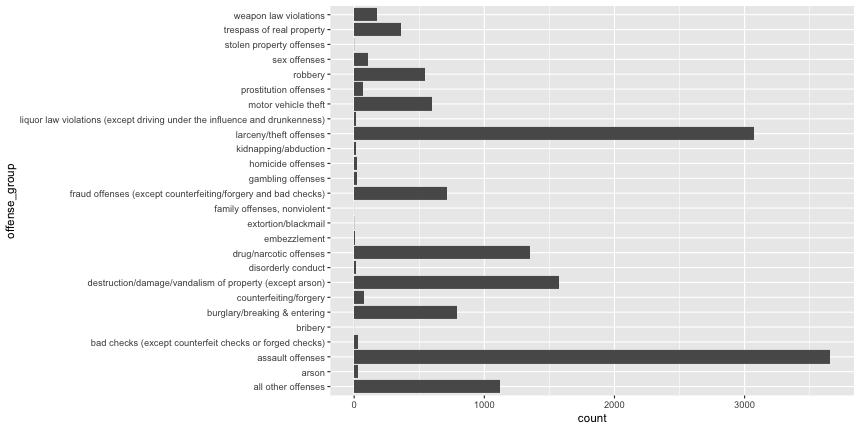

```r
dat %>%
  ggplot(aes(offense_group)) +
  geom_bar() +
  coord_flip()
```

And that these offenses tool place at different locations in the city.

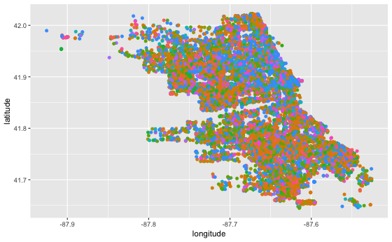

```r
dat %>%
  ggplot(aes(longitude,latitude,color=offense_group)) +
  geom_point(show.legend = F)
```

Let’s only look at the most prominent forms of crime. Let’s say that crimes that occur more than 500 times across the relevant period.

```r
dat <-
  dat %>%
  group_by(offense_group) %>%
  mutate(total_n = n()) %>%
  ungroup %>%
  filter(total_n >= 500)
```

This leaves us with the following offenses.

```r
unique(dat$offense_group)
```

```
[1] "fraud offenses (except counterfeiting/forgery and bad checks)"
[2] "assault offenses"
[3] "robbery"
[4] "burglary/breaking & entering"
[5] "larceny/theft offenses"
[6] "all other offenses"
[7] "destruction/damage/vandalism of property (except arson)"
[8] "drug/narcotic offenses"
[9] "motor vehicle theft"
```

# The AIM

Let’s build a **Shiny application** where we can **highlight** where the different offenses were most prominent in the city.

# Spatial Map

First, it would be useful if we were able to bin where each activity took place on a map of Chicago Neighborhoods.

Let’s use what we learned last week to build this map using the shapefile in the data folder.

```r
geo = st_read("Data/Chicago-Communities/chicago_neighborhoods.shp")
```

```r
head(geo)
```

```
Simple feature collection with 6 features and 9 fields
geometry type:  MULTIPOLYGON
dimension:      XY
bbox:           xmin: -87.7069 ymin: 41.79448 xmax: -87.58001 ymax: 41.99076
epsg (SRID):    4326
proj4string:    +proj=longlat +ellps=WGS84 +no_defs
  area area_num_1 area_numbe comarea comarea_id       community perimeter shape_area shape_len
1    0         35         35       0          0         DOUGLAS         0   46004621  31027.05
2    0         36         36       0          0         OAKLAND         0   16913961  19565.51
3    0         37         37       0          0     FULLER PARK         0   19916705  25339.09
4    0         38         38       0          0 GRAND BOULEVARD         0   48492503  28196.84
5    0         39         39       0          0         KENWOOD         0   29071742  23325.17
6    0          4          4       0          0  LINCOLN SQUARE         0   71352328  36624.60
                        geometry
1 MULTIPOLYGON (((-87.60914 4...
2 MULTIPOLYGON (((-87.59215 4...
3 MULTIPOLYGON (((-87.6288 41...
4 MULTIPOLYGON (((-87.60671 4...
5 MULTIPOLYGON (((-87.59215 4...
6 MULTIPOLYGON (((-87.67441 4...
```

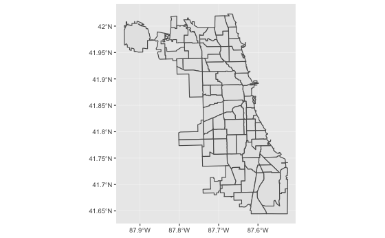

```r
geo %>%
  ggplot() +
  geom_sf()
```

Second, now that we have a map of Chicago Neighborhoods. Let’s overlay the event data on it. We can do this by first converting our points to an SF geometry object.

```r
dat2 = st_as_sf(dat, coords = c('longitude','latitude'))
st_crs(dat2) <- st_crs(geo) # Make sure the projections are the "same"
head(dat2)
```

```
Simple feature collection with 6 features and 12 fields
geometry type:  POINT
dimension:      XY
bbox:           xmin: -87.76191 ymin: 41.76046 xmax: -87.63387 ymax: 41.94799
epsg (SRID):    4326
proj4string:    +proj=longlat +ellps=WGS84 +no_defs
```

| uid | city_name | offense_code | offense_type | offense_group | offense_against | date_single | location_type | location_category | census_block | month | total_n | geometry |
| --- | --- | --- | --- | --- | --- | --- | --- | --- | --- | --- | --- | --- |
| 1957842 | Chicago | 26C | impersonation | fraud offenses (except counterfeiting/forgery and bad checks) | property | 2012-01-01 00:00:00 | residence | residence | 1.703166e+14 | 2012-01-01 | 715 |  |
| 1958151 | Chicago | 13A | aggravated assault | assault offenses | persons | 2012-01-01 01:20:00 | vehicle parking | open space | 1.703134e+14 | 2012-01-01 | 3660 |  |
| 1958164 | Chicago | 12A | personal robbery | robbery | property | 2012-01-01 01:30:00 | street | street | 1.703183e+14 | 2012-01-01 | 542 |  |
| 1958184 | Chicago | 13B | simple assault | assault offenses | persons | 2012-01-01 01:55:00 | residence | residence | 1.703167e+14 | 2012-01-01 | 3660 |  |
| 1958359 | Chicago | 13B | simple assault | assault offenses | persons | 2012-01-01 04:00:00 | street | street | 1.703161e+14 | 2012-01-01 | 3660 |  |
| 1958443 | Chicago | 12A | personal robbery | robbery | property | 2012-01-01 06:25:00 | street | street | 1.703115e+14 | 2012-01-01 | 542 |  |

Then we can join this data.

```r
dat3 <- st_join(geo,dat2,join=st_intersects)
```

```
although coordinates are longitude/latitude, st_intersects assumes that they are planar
```

```r
head(dat3)
```

```
Simple feature collection with 6 features and 21 fields
geometry type:  MULTIPOLYGON
dimension:      XY
bbox:           xmin: -87.62997 ymin: 41.82368 xmax: -87.6027 ymax: 41.84573
epsg (SRID):    4326
proj4string:    +proj=longlat +ellps=WGS84 +no_defs
    area area_num_1 area_numbe comarea comarea_id community perimeter shape_area shape_len     uid city_name
1      0         35         35       0          0   DOUGLAS         0   46004621  31027.05 1985054   Chicago
1.1    0         35         35       0          0   DOUGLAS         0   46004621  31027.05 1992645   Chicago
1.2    0         35         35       0          0   DOUGLAS         0   46004621  31027.05 2021761   Chicago
1.3    0         35         35       0          0   DOUGLAS         0   46004621  31027.05 2023478   Chicago
1.4    0         35         35       0          0   DOUGLAS         0   46004621  31027.05 2023587   Chicago
1.5    0         35         35       0          0   DOUGLAS         0   46004621  31027.05 2031165   Chicago
    offense_code       offense_type          offense_group offense_against         date_single location_type
1            13B     simple assault       assault offenses         persons 2012-02-02 08:50:00  other retail
1.1          90Z all other offenses     all other offenses           other 2012-02-11 15:54:00     residence
1.2          13B     simple assault       assault offenses         persons 2012-03-16 20:30:00        street
1.3          13B     simple assault       assault offenses         persons 2012-03-18 13:45:00     residence
1.4          23H        other theft larceny/theft offenses        property 2012-03-18 16:52:00     residence
1.5          90Z all other offenses     all other offenses           other 2012-03-26 15:30:00         other
    location_category census_block      month total_n                       geometry
1              retail 1.703135e+14 2012-02-01    3660 MULTIPOLYGON (((-87.60914 4...
1.1         residence 1.703184e+14 2012-02-01    1121 MULTIPOLYGON (((-87.60914 4...
1.2            street 1.703135e+14 2012-04-01    3660 MULTIPOLYGON (((-87.60914 4...
1.3         residence 1.703135e+14 2012-04-01    3660 MULTIPOLYGON (((-87.60914 4...
1.4         residence 1.703135e+14 2012-04-01    3076 MULTIPOLYGON (((-87.60914 4...
1.5             other 1.703184e+14 2012-04-01    1121 MULTIPOLYGON (((-87.60914 4...
```

Let’s now aggregate by event type for each offense for each community/neighborhood. Geospatial objects are fickle. So let’s reduce this feature as data frame then merge back onto the data features we care about.

```r
tmp <-
  dat3 %>%
  as.data.frame() %>%
  group_by(community,offense_group) %>%
  count()
head(tmp)
```

| community | offense_group | n |
| --- | --- | --- |
| ALBANY PARK | all other offenses | 7 |
| ALBANY PARK | assault offenses | 33 |
| ALBANY PARK | burglary/breaking & entering | 13 |
| ALBANY PARK | destruction/damage/vandalism of property (except arson) | 18 |
| ALBANY PARK | drug/narcotic offenses | 10 |
| ALBANY PARK | fraud offenses (except counterfeiting/forgery and bad checks) | 9 |

```r
dat4 <-
  dat3 %>%
  select(geometry,community) %>%
  left_join(tmp,by="community") %>%
  unique() # Eliminate redundancies
dat4
```

```
Simple feature collection with 666 features and 3 fields
geometry type:  MULTIPOLYGON
dimension:      XY
bbox:           xmin: -87.94011 ymin: 41.64454 xmax: -87.52414 ymax: 42.02304
epsg (SRID):    4326
proj4string:    +proj=longlat +ellps=WGS84 +no_defs
First 10 features:
     community                                                 offense_group  n                       geometry
1      DOUGLAS                                            all other offenses 10 MULTIPOLYGON (((-87.60914 4...
2      DOUGLAS                                              assault offenses 29 MULTIPOLYGON (((-87.60914 4...
3      DOUGLAS                                  burglary/breaking & entering  1 MULTIPOLYGON (((-87.60914 4...
4      DOUGLAS       destruction/damage/vandalism of property (except arson) 13 MULTIPOLYGON (((-87.60914 4...
5      DOUGLAS                                        drug/narcotic offenses 11 MULTIPOLYGON (((-87.60914 4...
6      DOUGLAS fraud offenses (except counterfeiting/forgery and bad checks)  3 MULTIPOLYGON (((-87.60914 4...
7      DOUGLAS                                        larceny/theft offenses 38 MULTIPOLYGON (((-87.60914 4...
8      DOUGLAS                                           motor vehicle theft  8 MULTIPOLYGON (((-87.60914 4...
9      DOUGLAS                                                       robbery  9 MULTIPOLYGON (((-87.60914 4...
1099   OAKLAND                                            all other offenses  6 MULTIPOLYGON (((-87.59215 4...
```

Now let’s visualize again just to make sure everything went as planned.

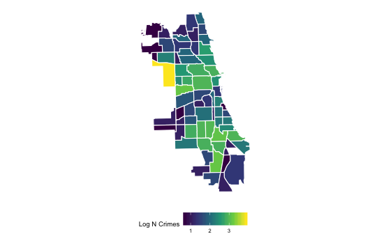

```r
dat4 %>%
  filter(offense_group == "robbery") %>%
  ggplot() +
  geom_sf(aes(fill=log(n+1)),color="white") +
  ggthemes::theme_map() +
  scale_fill_viridis_c() +
  labs(fill="Log N Crimes") +
  theme(panel.grid.major = element_line(colour = "white"),
        legend.position = "bottom")
```

The data appears in order. Let’s save it as a `.rds` file (R data storage) so that we can read it in easily for our future use.

```r
write_rds(dat4,"Data/chicago_crime_spatial.rds")
```

# Build Shiny App

Construct the “user interface”.

```r
ui <- fluidPage(

    # Application title
    titlePanel("The Distribution of Crime in Chicago"),

    # Sidebar with selection options for the different crime types
    sidebarLayout(
        sidebarPanel(
            selectInput(inputId = "crimes",choices = unique(dat4$offense_group),
                        label = "Select Crime Type",selected = "robbery")
        ),

        mainPanel(
           plotOutput("map")
        )
    )
)
```

Construct the Server.

```r
server <- function(input, output) {

    output$map <- renderPlot({
      dat4 %>%
        filter(offense_group == input$crimes) %>%
        ggplot() +
        geom_sf(aes(fill=log(n+1)),color="white") +
        ggthemes::theme_map() +
        scale_fill_viridis_c() +
        labs(fill="Log N Crimes") +
        theme(panel.grid.major = element_line(colour = "white"),
              legend.position = "bottom")
    })

}
```

Run Application

```r
shinyApp(ui = ui, server = server)
```

```
Listening on http://127.0.0.1:7293
```

```
NA
```

## More Advanced

We can build on top of this current application to offer more information.

The User Interface again…

```r
ui <- fluidPage(

    # Application title
    titlePanel("The Distribution of Crime in Chicago"),

    # Sidebar with selection options for the different crime types
    sidebarLayout(
        sidebarPanel(
            selectInput(inputId = "crimes",choices = unique(dat4$offense_group),
                        label = "Select Crime Type",selected = "robbery")
        ),

        mainPanel(
          plotOutput("frequency"),
          plotOutput("map")
        )
    )
)
```

Now the Server….

```r
server <- function(input, output) {

    output$map <- renderPlot({
      dat4 %>%
        filter(offense_group == input$crimes) %>%
        ggplot() +
        geom_sf(aes(fill=log(n+1)),color="white") +
        ggthemes::theme_map() +
        scale_fill_viridis_c() +
        labs(fill="Log N Crimes") +
        theme(panel.grid.major = element_line(colour = "white"),
              legend.position = "bottom")
    })

    output$frequency <- renderPlot({
      dat %>%
        filter(offense_group == input$crimes) %>%
        ggplot() +
        geom_bar(aes(x=month),fill="steelblue",color="white") +
        theme_minimal() +
        labs(title=str_glue("Number of '{str_to_title(input$crimes)}' by Month"),
             y = "Number of Crimes",
             x="Date by Month")
    })

}
```

Run Application

```r
shinyApp(ui = ui, server = server)
```

```
Listening on http://127.0.0.1:7293
```

```
NA
```